# Final Homework

Math 424 Kafai by Jonathan Dombrowski

## Q1.

Consider the data in q1data.txt. All subjects are asthmatics. For the model with Forced Expiratory Volume (FEV) as the response and Height, Weight, and Age as the predictors,

1. Examine a plot of the studentized or jackknife residuals versus the predicted values. Are any regression assumption violations apparent? If so, suggest possible remedies.
2. Examine numerical descriptive statistics, histograms, box-and-whisker plots, and normal probability plots of jackknife residuals. Is the normality assumption violated? If so, suggest possible remedies.
3. Examine outlier diagnostics, including Cook’s distance, leverage statistics, and jackknife residuals, and identify any potential outliers. What course of action, if any, should be taken when outliers are identified?
4. Examine variance inflation factors, condition i.Ildices (unadjusted and adjusted for the intercept), and variance proportions. Are there any important collinearity problems? If so, suggest possible remedies.

### Work

loading in data, had to trim the second row in order for R not to have the data be forcibly read as factors. The units are as follows

age sex Height Weight FEV (yr) (m/f) (cm) (kg) (L)

|  | age | sex | Height | Weight | FEV |
| --- | --- | --- | --- | --- | --- |
| 1 | 24 | M | 175 | 78.0 | 4.7 |
| 2 | 36 | M | 172 | 67.6 | 4.3 |
| 3 | 28 | F | 171 | 98.0 | 3.5 |
| 4 | 25 | M | 166 | 65.5 | 4.0 |
| 5 | 26 | F | 166 | 65.0 | 3.2 |
| 6 | 22 | M | 176 | 65.5 | 4.7 |

### a)

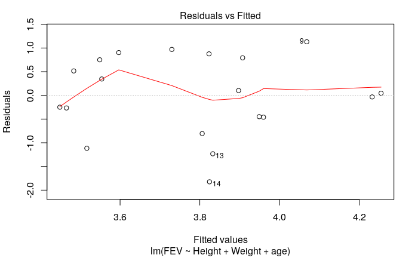

#### b)

```r
summary(df)
```

```
      age        sex        Height          Weight           FEV
 Min.   :22.00   F: 3   Min.   :163.0   Min.   :62.00   Min.   :2.000
 1st Qu.:25.50   M:16   1st Qu.:169.5   1st Qu.:65.50   1st Qu.:3.200
 Median :27.00          Median :175.0   Median :70.40   Median :4.000
 Mean   :29.21          Mean   :174.7   Mean   :73.72   Mean   :3.784
 3rd Qu.:32.00          3rd Qu.:180.0   3rd Qu.:78.50   3rd Qu.:4.400
 Max.   :46.00          Max.   :185.0   Max.   :98.00   Max.   :5.200
```

The sum of the residuals is $-3.191891\times10^{-16}$, which means that the assumption that the sum of the residuals is zero is not violated.

#### c)

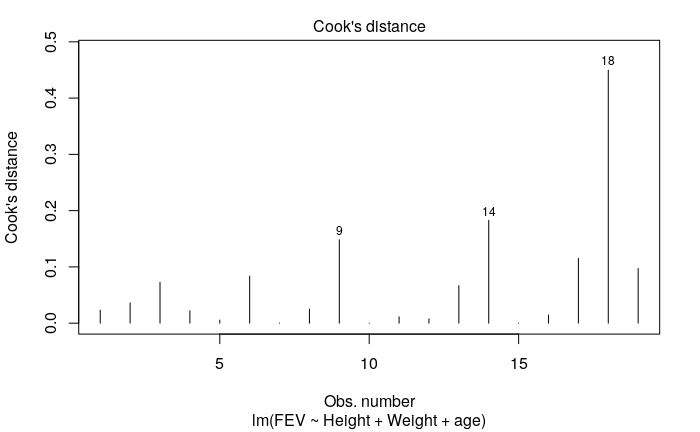

Based on this readout, there does not seem to be anything in violating cooks distance, but 18 is very close. However it does not cross the 0.5 threshold so it does not have a large enough leverage over the model to warrant removal of the data point.

For leverage to be considered too influential to be included,its’ influence must be greater than the $\bar{2h}= \frac{2(k+1)}{n}= \frac{8}{19}=0.421$ Checking the residuals:

```r
test$hat
```

```
         1          2          3          4          5          6          7          8          9
0.10058063 0.15451273 0.40791648 0.18462242 0.17948081 0.22260701 0.25136736 0.07664059 0.23136625
        10         11         12         13         14         15         16         17         18
0.25161157 0.14078489 0.24386941 0.11626740 0.13807883 0.09943096 0.23776177 0.29673065 0.48828227
        19
0.17808797
```

From this we can see that only the point 18 is considered too influential to be included in the mode therefore we must suggest that 18 be removed from the model, and this test be redone until all values are withing the influence threshold.

#### Multicollinearity

Testing for multicollinearity, we will test whether or not any of the terms has a variable inflation(VIF) of over 10; whether or not $VIF_i = \frac{1}{1-R^2_i} \forall i = 1:k$, where $R^2_i$ is the multiple coefficient for the model.

```r
vif(df)
```

```
Error in y[, i] : incorrect number of dimensions
```

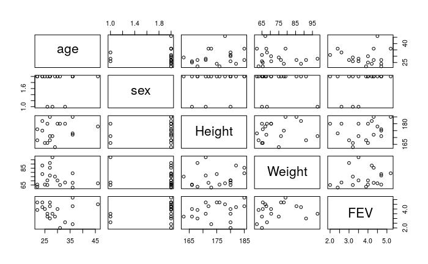

From this, we do not detect any collinearity problems.

### Q2.

A random sample of data was collected on residential sales in a large city. The data in q2data.txt shows the selling price (Y, in $1,000s), area (x1, in hundreds of square feet), number of bedrooms (X2), total number of rooms (X3), house age (X4, in years), and location (Z = 0 for in-town and inner suburbs, Z=1for outer suburbs). In parts a through c, use variables X1, X2, X3, X4, and Z as the predictor variables.

1. Use the all possible regressions procedure to suggest a best model.
2. Use the stepwise regression algorithm to suggest a best model.
3. Use the backward elimination algorithm to suggest a best model.
4. Which of the models selected in a, b, and c seems to be the best model, and why?

### Work

First we will create the base model in which we can work from:

```r
library(olsrr)
df <- read.table(file = "q2data.txt", header = TRUE)
head(df)
```

|  | House | y | x1 | x2 | x3 | x4 | Z |
| --- | --- | --- | --- | --- | --- | --- | --- |
| 1 | 1 | 84.0 | 13.8 | 3 | 7 | 10 | 0 |
| 2 | 2 | 93.0 | 19.0 | 2 | 7 | 22 | 1 |
| 3 | 3 | 83.1 | 10.0 | 2 | 7 | 15 | 1 |
| 4 | 4 | 85.2 | 15.0 | 3 | 7 | 12 | 1 |
| 5 | 5 | 85.2 | 12.0 | 3 | 7 | 8 | 1 |
| 6 | 6 | 85.2 | 15.0 | 3 | 7 | 12 | 1 |

```r
model_Base = lm(y~x1+x2+x3+x4+Z, data = df)
summary(model_Base)
```

```
Call:
lm(formula = y ~ x1 + x2 + x3 + x4 + Z, data = df)

Residuals:
     Min       1Q   Median       3Q      Max
-14.5202  -2.1010  -0.3284   2.8291   5.9076

Coefficients:
            Estimate Std. Error t value Pr(>|t|)
(Intercept)  -6.4272    11.7583  -0.547  0.58969
x1            0.8858     0.6167   1.436  0.16380
x2            3.6402     2.7122   1.342  0.19210
x3            8.8312     2.7210   3.246  0.00344 **
x4            0.6048     0.3286   1.840  0.07811 .
Z             0.5901     2.2309   0.265  0.79362
---
Signif. codes:  0 ‘***’ 0.001 ‘**’ 0.01 ‘*’ 0.05 ‘.’ 0.1 ‘ ’ 1

Residual standard error: 4.942 on 24 degrees of freedom
Multiple R-squared:  0.8351,    Adjusted R-squared:  0.8007
F-statistic: 24.31 on 5 and 24 DF,  p-value: 1.146e-08
```

### a) All possible subsets

Since we used Mallows Cp statistic for the previous homework, we will use it here. If we look at the Cp scores for the different variable numbers, we can see that 3 variables is where the minimum Cp value exists and there for the correct place to stop the regression.

```r
bestSubsetData
```

```
  Best Subsets Regression
----------------------------
Model Index    Predictors
----------------------------
     1         x3
     2         x1 x3
     3         x1 x3 x4
     4         x1 x2 x3 x4
     5         x1 x2 x3 x4 Z
----------------------------

                                                    Subsets Regression Summary
----------------------------------------------------------------------------------------------------------------------------------
                       Adj.        Pred
Model    R-Square    R-Square    R-Square     C(p)        AIC         SBIC        SBC        MSEP        FPE       HSP       APC
----------------------------------------------------------------------------------------------------------------------------------
  1        0.7417      0.7325      0.6243    11.5912    193.7680    107.7423    197.9715    35.1353    34.9733    1.2144    0.2952
  2        0.8069      0.7926      0.6898     4.0972    187.0350    102.2958    192.6398    28.2817    27.9558    0.9775    0.2360
  3        0.8224      0.8019      0.7069     3.8492    186.5333    102.6300    193.5393    28.1004    27.5177    0.9712    0.2323
  4        0.8346      0.8081      0.6979     4.0700    186.3938    103.5998    194.8010    28.3467    27.4323    0.9797    0.2316
  5        0.8351      0.8007      0.6824     6.0000    188.3064    106.0451    198.1148    30.7221    29.3063    1.0618    0.2474
----------------------------------------------------------------------------------------------------------------------------------
AIC: Akaike Information Criteria
 SBIC: Sawa's Bayesian Information Criteria
 SBC: Schwarz Bayesian Criteria
 MSEP: Estimated error of prediction, assuming multivariate normality
 FPE: Final Prediction Error
 HSP: Hocking's Sp
 APC: Amemiya Prediction Criteria
```

The readout states that the lowest Cp value, that is near P+1 (with P= number of predictors ) contains 3 variables, and follows the form: $E(y)=\beta_0 + \beta_1x_1 +\beta_3x_3+\beta_4x_4$ Building and testing this model:

```r
summary(modelSS)
```

```
Call:
lm(formula = y ~ x1 + x3 + x4, data = df)

Residuals:
     Min       1Q   Median       3Q      Max
-15.9171  -1.2529   0.5481   1.7545   7.4792

Coefficients:
            Estimate Std. Error t value Pr(>|t|)
(Intercept)  -4.9227    10.5624  -0.466    0.645
x1            0.8148     0.5320   1.532    0.138
x3           10.5264     2.0628   5.103 2.56e-05 ***
x4            0.4580     0.3046   1.504    0.145
---
Signif. codes:  0 ‘***’ 0.001 ‘**’ 0.01 ‘*’ 0.05 ‘.’ 0.1 ‘ ’ 1

Residual standard error: 4.928 on 26 degrees of freedom
Multiple R-squared:  0.8224,    Adjusted R-squared:  0.8019
F-statistic: 40.12 on 3 and 26 DF,  p-value: 6.701e-10
```

$H_o : \beta_1=\beta_3=\beta_4 = 0$

$H_a : \beta_i \neq \beta_j , i\neq j$

p:value 6.701$\times 10^{-10}$

$R^2$ = 0.8224